# Group Lab 1 - Changes in the Geography of Chinese Production

Group 2: Jin Chang, Carmelita Deleon, Kevin Ho, Billy Wang, Alisha Husain

1/25/2019

# Part 1

Cities like Beijing and Shanghai are included in the list of provinces in this dataset because they are municipalities. In China, a municipality is a “city”[^1] with “provincial” power under the unified jurisdiction of the central government. This means that Beijing and Shanghai are considered both cities and provinces. Furthermore, there are a few locations excluded in this dataset that some viewers might argue are “missing”. For example, the People’s Republic of China claims Taiwan and its surrounding islets as “Taiwan Province”, even though Taiwan has been independent from China since 1949. If someone were interested in finding economic statistical information about Taiwan, they would have to visit the website on National Statistics for the Republic of China (Taiwan). Another province that has a large amount of economic data missing from this dataset is the Tibet province; Tibet has been occupied by China since 1965, when it established the “Tibetan Autonomous Region”. From our dataset, it is evident that regular reporting of enterprise and output about this region only became available after China’s establishment of the TAR.

There are several problems with Chinese statistics that cause unreliability and uncertainty. The first problem is that when China began its major economic transformation in the late 1970s, changing from a command economy to a market economy, the transformation happened faster than China’s National Bureau of Statistics had prepared itself for. The result was a major challenge in collecting measurements, because many of these new private service-sector businesses did not report their activity directly to the NBS until the 1990s. This means that the period of 1970-1990 is less reliable for China’s economic data. Another issue is that in 1993, China changed its methods of calculating its GDP to the United Nations’ standards - however, these concepts were very new to the statisticians in China and would take time to adopt. The challenge of overhauling the country’s statistical system makes accurately measuring growth during the transition period unlikely. [Source](https://www.stlouisfed.org/publications/regional-economist/second-quarter-2017/chinas-economic-data-an-accurate-reflection-or-just-smoke-and-mirrors

Furthermore, additional [sources] (https://www.forbes.com/sites/unicefusa/2019/01/23/a-step-closer-to-adulthood-along-a-cold-highway/#7aec101a1632) argue that “there are enormous discrepancies both within NBSC data and then when comparing it to outside data. These discrepancies come from both poor quality statistical management but also unquestionably data manipulation”. Critics have offered several recommendations to help fight data falsification at the provincial and individual levels. These include recommendations to introduce measures to check the quality of data collection, corrections for exaggeration, better methodology, and improving timeliness and periodicity of data releases.

# Part 2

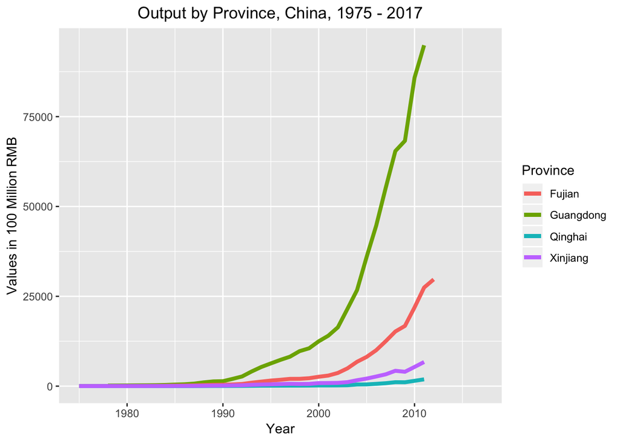

Here we have a chart showing the output, in 100 million RMB, for 4 Provinces in China from 1975 through 2017. Output has been relatively flat for these 4 provinces up until 1990. At around that point, there appears to be a divergence in output increase, with some provinces experiencing greater output growth than others. What might explain this? Qinghai and Xinjiang are on the **western** part of the country, where the terrain is *mountainous* and *fragmented*, isolating those areas from the rest of the country. On the other hand, Guangdong and Fujian are along the coast where industrialization and economic activity are greater [(Batisse 2005)](https://journals.openedition.org/chinaperspectives/502).

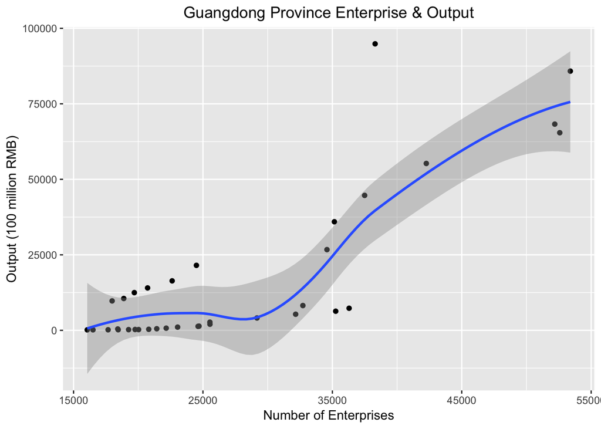

Focusing in on Guangdong Province from the previous chart, this chart displays the **relationship** between the number of enterprises and output. Generally, the *greater* the number of enterprises the *greater* the output. Howerver, that isn’t always the case as there are some instances of lower numbers of enterprises yet high output. When there are **low** numbers of enterprises but output remains **high**, that may be an indicator for *greater* instances of mergers/acquisitions and/or *increased* productivity.

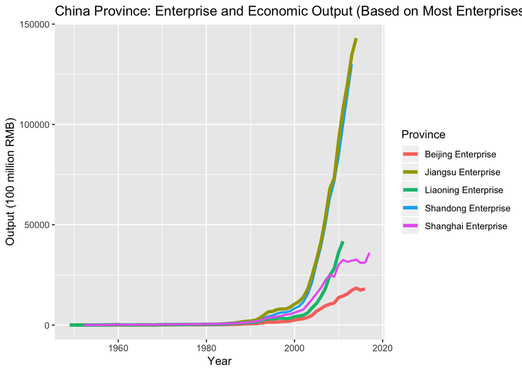

Here are the **top 5** provinces and the output that they produced from the years *1949* to *2017*. These provinces had the greatest enterprises from the start of 1949. As shown, all five started with *low outputs*. After 1990 is when all five companies started to disperse with *different* values in output. Jiangsu Enterprise has the *highest* output with about 143016.94 hundred million RMB in the year 2014 followed by Shandong Enterprise as a close second with an output of 129906 hundred million RMB in the year 2013. Beijing Enterprise has the *lowest value* of output of 18087.27 hundred million RMB in the year 2016.

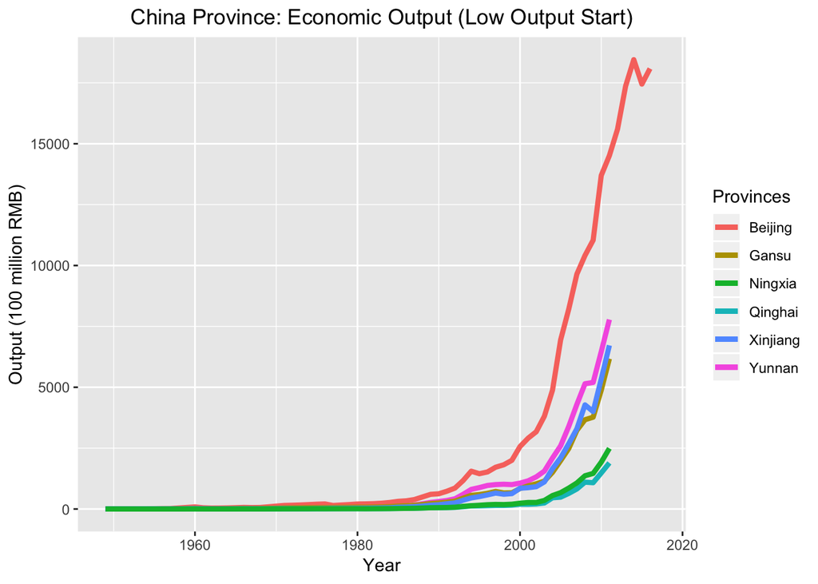

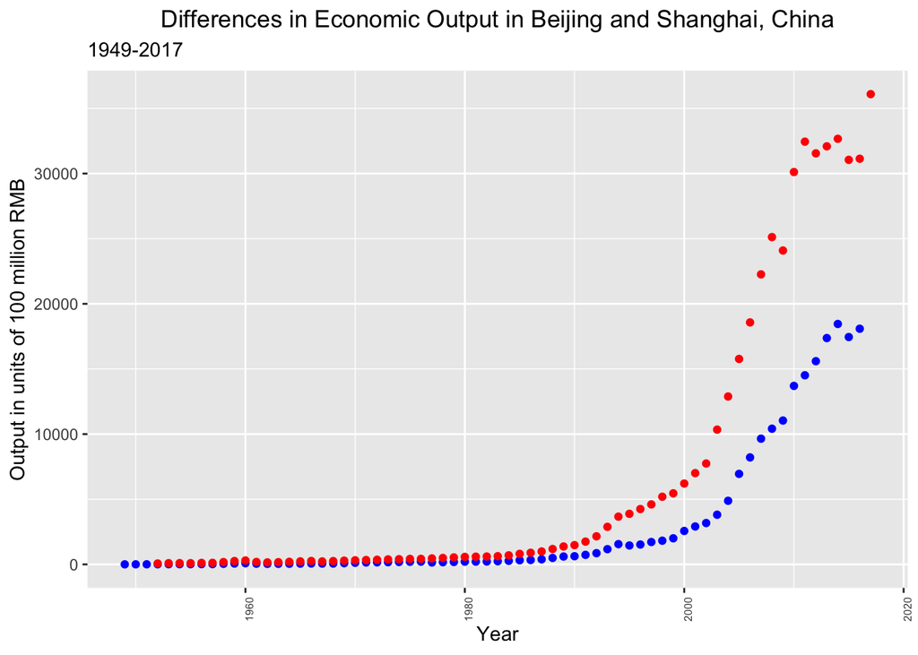

Beijing is symbolized by the blue dots, Shanghai is symbolized by the red dots.

The purpose of this visualization is to compare the economic output between the two *wealthiest* provinces in China, Beijing and Shanghai. Up until around 1986, both provinces had roughly the same output, but after that year both provinces began to experience **exponential growth**, with Shanghai’s rate of increase in output being *higher* than Beijing’s.

# Part 3

## First

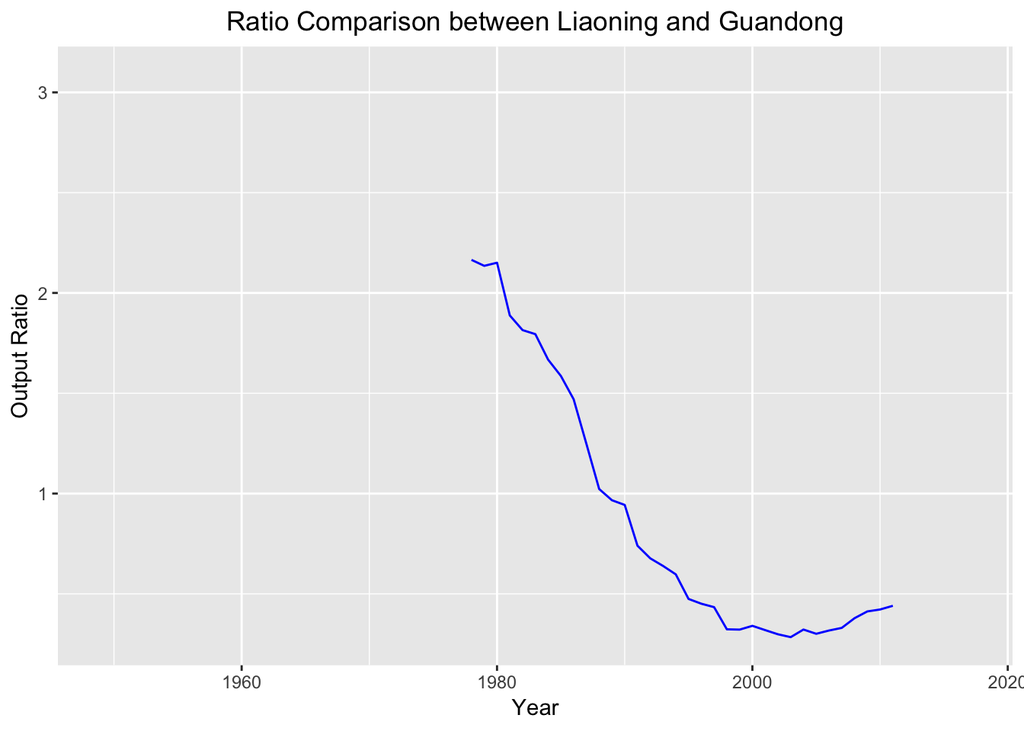

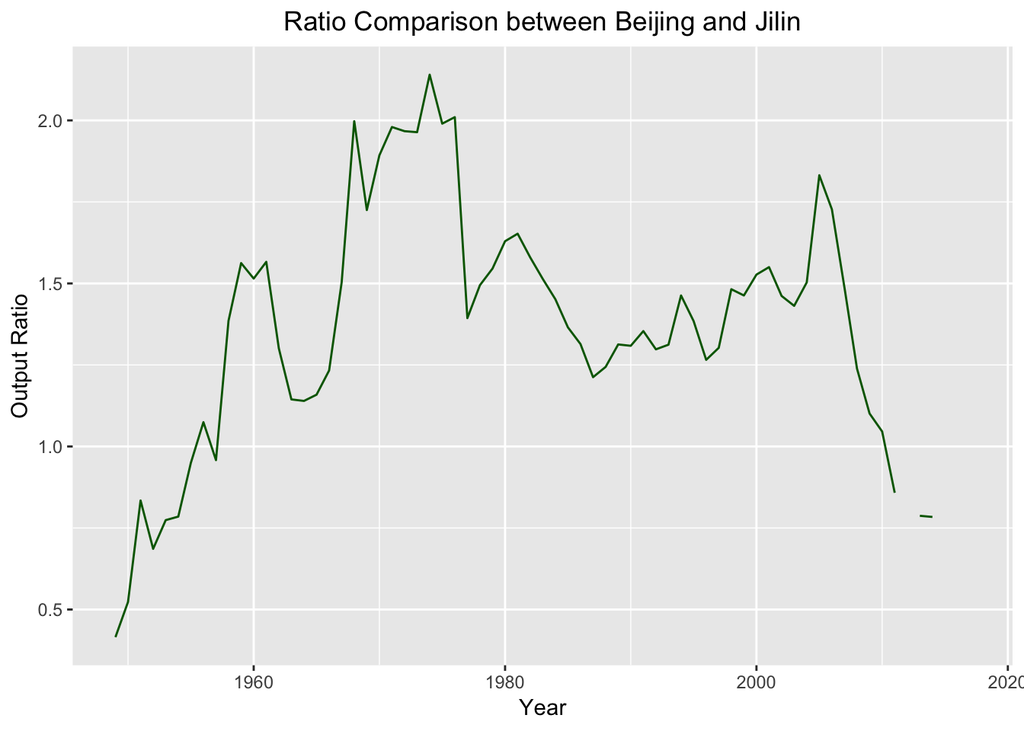

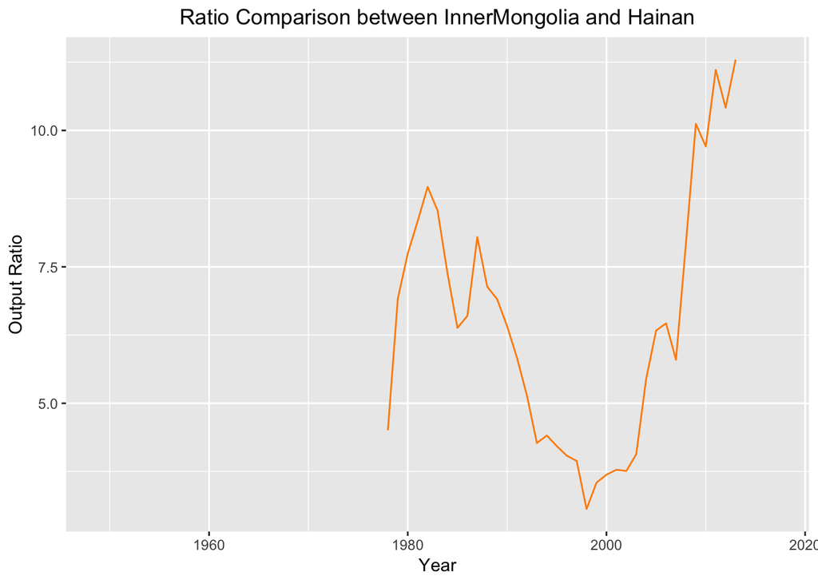

### How we treated NA Values

We did not modify or remove the NA values during the calculation or while plotting because we believe that there may be a *loss* in data. Furthermore, we believe the ommission of this values may impact the analysis **negatively**.

## Second

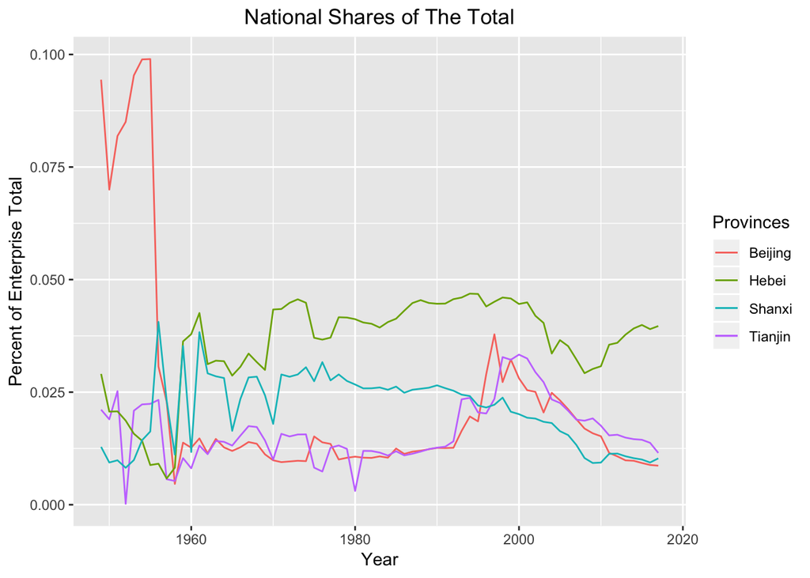

## Third

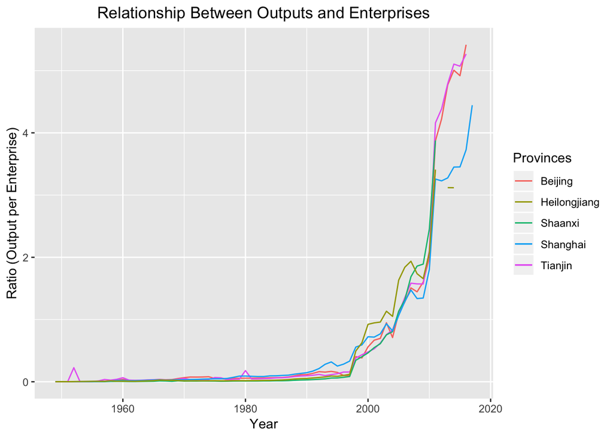

## Four, Five, and Six

Below we see population data gathered from the National Bureau of Statistics of China. Formatting of the original raw file was odd & difficult to work with, so I modified it and cleaned it in a separate file. Below you will see the Gross Domestic Populations of the first 10 provinces, so it matches up well with the Enterprise/Output data, as well as a cut year range from 2000 to 2017.

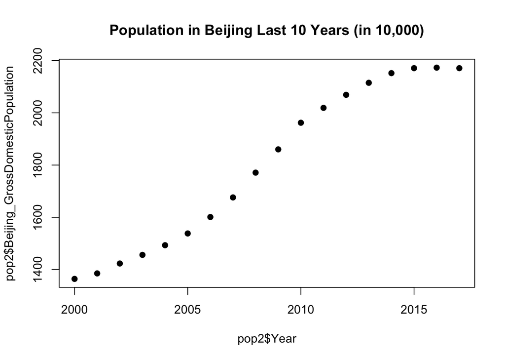

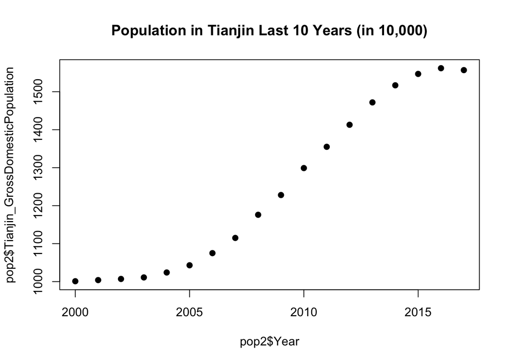

Here we see population graphs for both the province of Beijing as well as Tianjin. Notice how they similarly mark against one another in a logarithmic fashion. As previously mentioned, the timeframe of 2000 to 2017 was chosen purpusely as you can see from around 2000 to ~2010, China was experiencing huge population growth, to the point of exponential codification. However, post 2010 you see a sharp decline in the growth rate as exemplified below, taken as well from the Natural Bureau of of Statistics of China, which causes the progression from exponential growth to a more modest logarithmic.

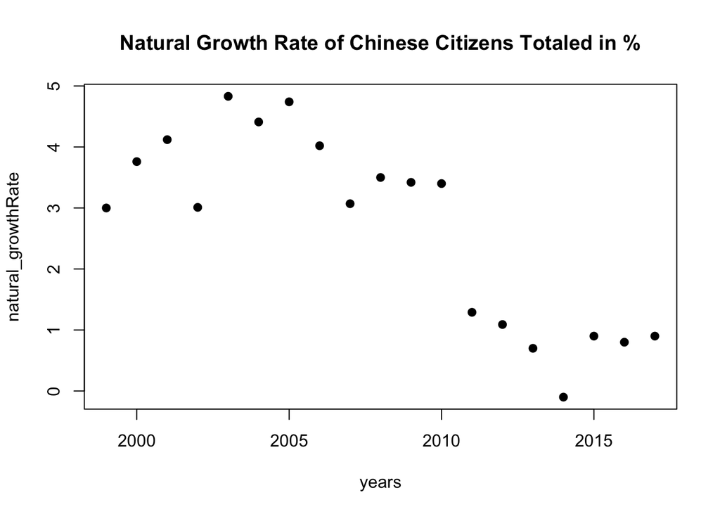

Next, we combine both the Enterprise/Output data, as well as the new Population Data, to check for hidden variables. We will normalize the Enterpise data to the Gross Domestic Population variable to limit the role of external factors and try and derive a relationship from it. Below you will see a function that takes in the province names of all ten listed and calculates it’s enterprise to population ratio, followed by a line plot to add contour to the pattern. It runs through Beijing then Tianjin then Hebei, etc so you the viewer can easily visually compare Enterprise/Population ratios from the top down.

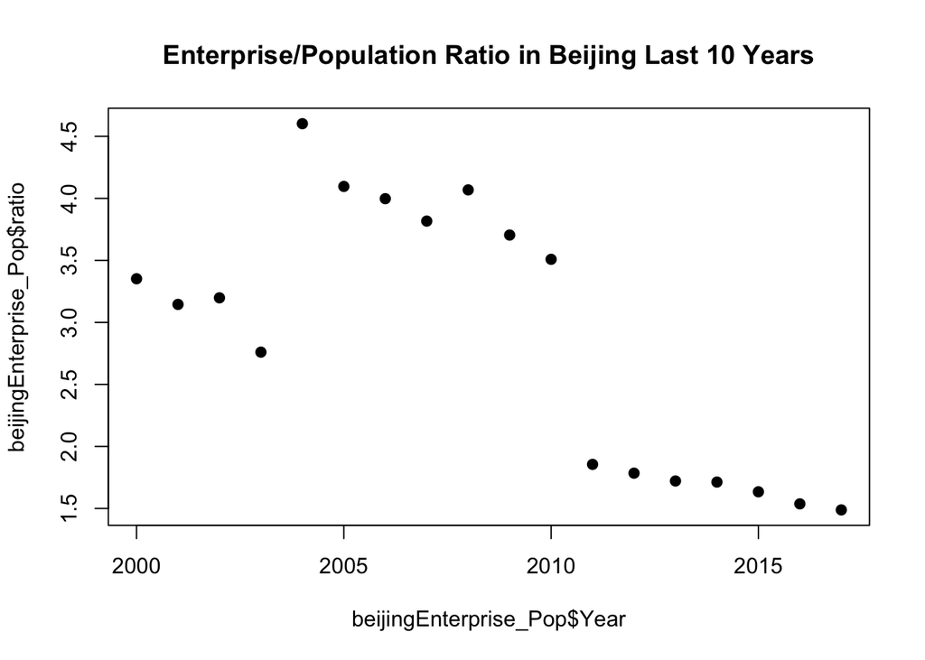

```
##    Beijing_Enterprise
## 1            3.351906
## 2            3.145126
## 3            3.198173
## 4            2.760302
## 5            4.602143
## 6            4.096229
## 7            3.997502
## 8            3.816826
## 9            4.068323
## 10           3.704301
## 11           3.508665
## 12           1.855374
## 13           1.784437
## 14           1.721513
## 15           1.712825
## 16           1.634270
## 17           1.537046
## 18           1.488254
```

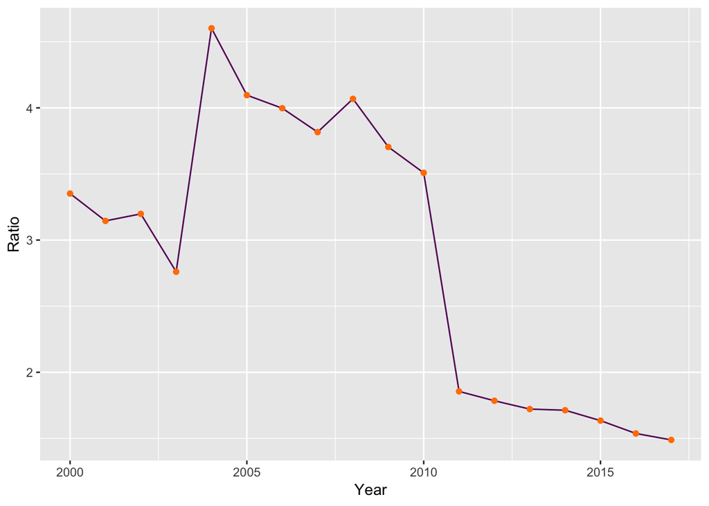

```
##    Tianjin_Enterprise
## 1            5.424575
## 2            5.538845
## 3            5.308838
## 4            5.282888
## 5            6.310547
## 6            5.890700
## 7            5.861395
## 8            5.704933
## 9            6.760204
## 10           6.780130
## 11           6.117783
## 12           3.699631
## 13           3.780609
## 14           3.743886
## 15           3.626236
## 16           3.571429
## 17           3.330986
## 18           2.752730
```

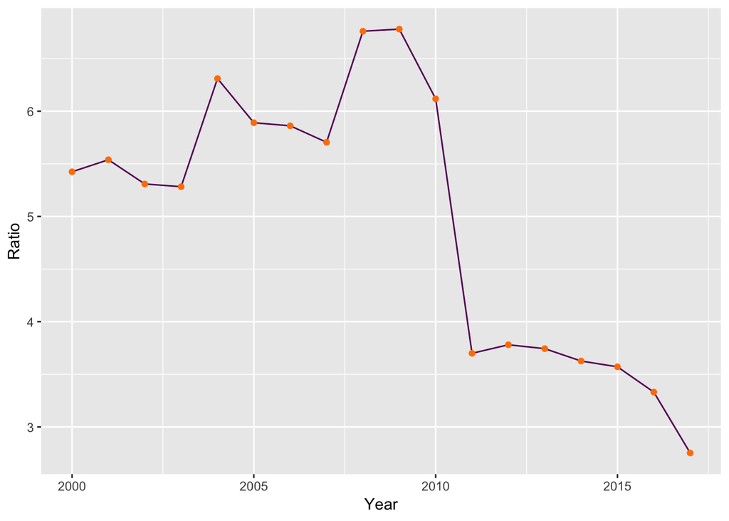

```
##    Hebei_Enterprise
## 1          1.087953
## 2          1.148828
## 3          1.131106
## 4          1.170483
## 5          1.363489
## 6          1.450299
## 7          1.541606
## 8          1.565606
## 9          1.780941
## 10         1.861814
## 11         1.935919
## 12         1.597846
## 13         1.710017
## 14         1.904814
## 15         2.003250
## 16         2.059933
## 17         1.976439
## 18         1.966755
```

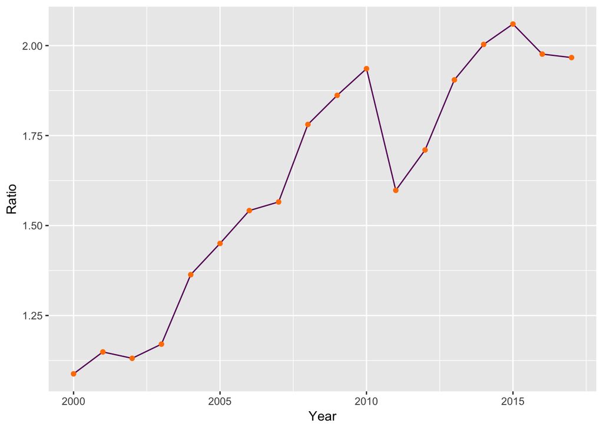

```
##    Shanxi_Enterprise
## 1          1.0086233
## 2          1.0110024
## 3          1.0546448
## 4          1.0902233
## 5          1.5031484
## 6          1.3236960
## 7          1.3831111
## 8          1.3180077
## 9          1.2943418
## 10         1.1739130
## 11         1.1863458
## 12         1.0228222
## 13         1.0814179
## 14         1.0961433
## 15         1.0707237
## 16         1.0493996
## 17         0.9636067
## 18         1.0359265
```

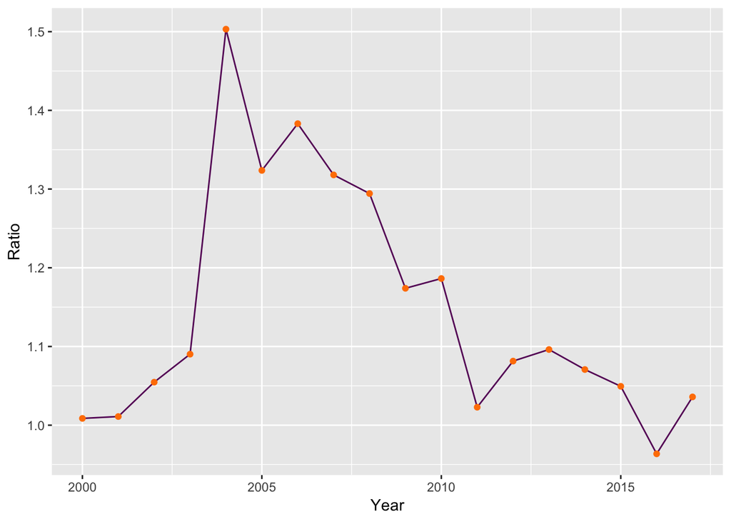

```
##    InnerMongolia_Enterprise
## 1                 0.5788364
## 2                 0.5791684
## 3                 0.6040268
## 4                 0.6927913
## 5                 0.9506895
## 6                 1.0183104
## 7                 1.2732919
## 8                 1.3849321
## 9                 1.6337971
## 10                1.8165175
## 11                1.8652913
## 12                1.6821112
## 13                1.7044177
## 14                1.7630104
## 15                1.7616766
## 16                1.7538829
## 17                1.9737690
## 18                1.1075524
```

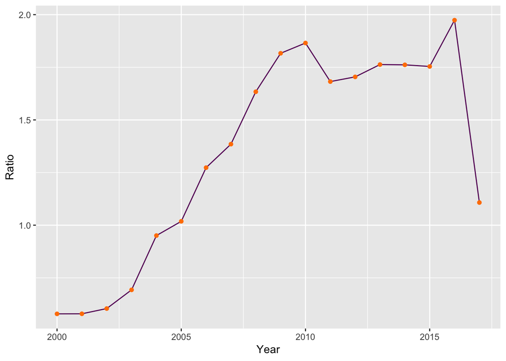

```
##    Liaoning_Enterprise
## 1             1.438098
## 2             1.394134
## 3             1.431596
## 4             1.625178
## 5             2.521935
## 6             2.726842
## 7             3.454460
## 8             3.852024
## 9             5.069757
## 10            5.382170
## 11            5.447314
## 12            3.859001
## 13            3.952381
## 14            3.941913
## 15           35.779043
## 16            2.807850
## 17            5.137644
## 18            1.516594
```

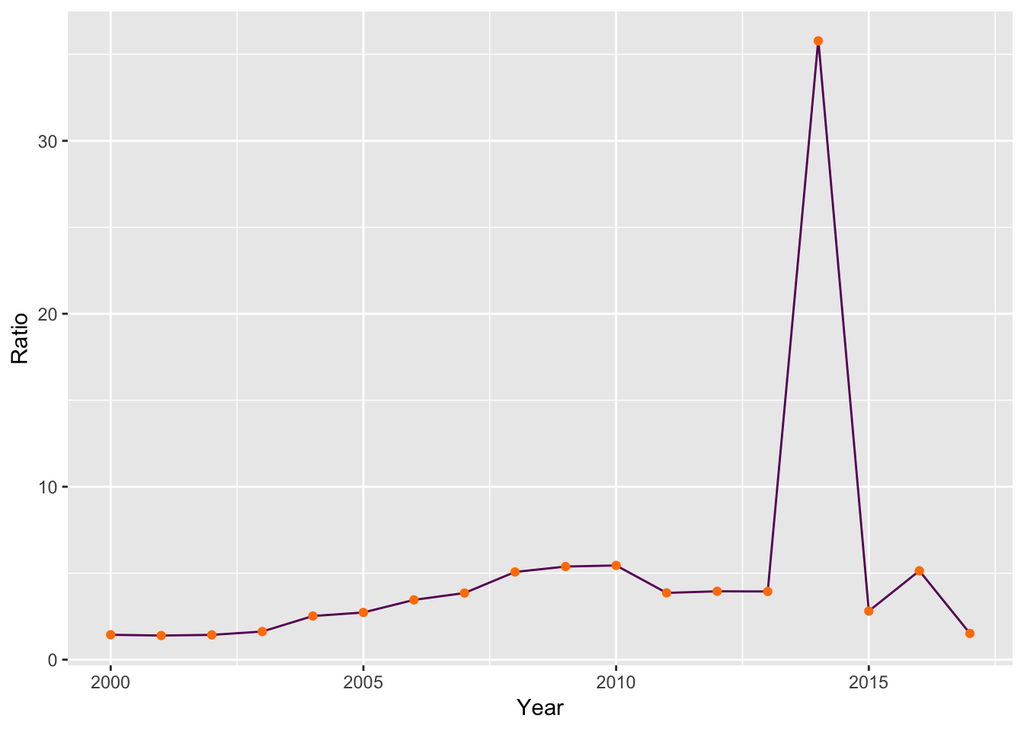

```
##    Jilin_Enterprise
## 1         1.0171514
## 2         0.9691564
## 3         0.9529455
## 4         0.8446746
## 5         1.2107789
## 6         1.0213549
## 7         1.1931693
## 8         1.4593407
## 9         1.9228237
## 10        2.1664234
## 11        2.2665933
## 12        1.8763187
## 13        1.9221818
## 14        1.9541985
## 15        1.9298692
## 16        2.0639303
## 17        0.8036145
## 18        2.1976445
```

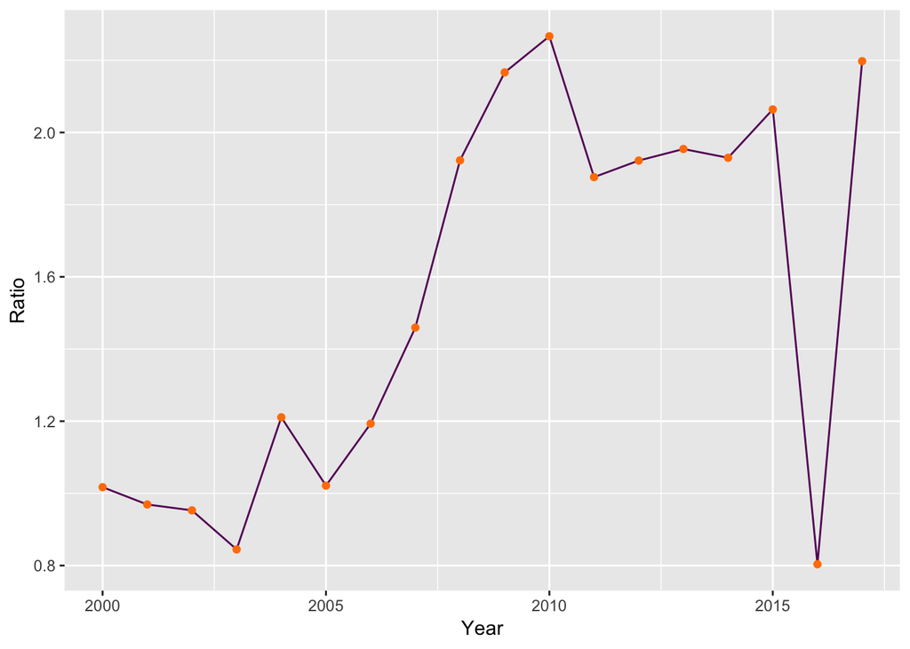

```
##    Heilongjiang_Enterprise
## 1                0.7002889
## 2                0.6559958
## 3                0.6800420
## 4                0.6728702
## 5                0.8637674
## 6                0.7557592
## 7                0.7732148
## 8                0.8294979
## 9                1.1482353
## 10               1.1521171
## 11               1.1990608
## 12               0.8808033
## 13               1.0200835
## 14               1.1468057
## 15               1.1231411
## 16               1.0918153
## 17               1.0717002
## 18               0.9846925
```

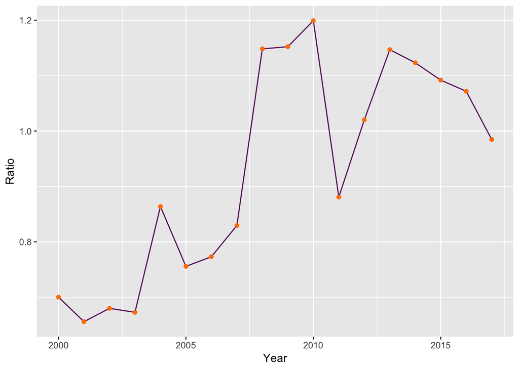

```
##    Shanghai_Enterprise
## 1             5.328776
## 2             5.852518
## 3             5.870987
## 4             6.284258
## 5             8.591826
## 6             7.835450
## 7             7.334012
## 8             7.315407
## 9             8.777207
## 10            8.102262
## 11            7.244464
## 12            4.244568
## 13            4.105882
## 14            4.056315
## 15            3.903133
## 16            3.724224
## 17            3.843074
## 18            3.358974
```

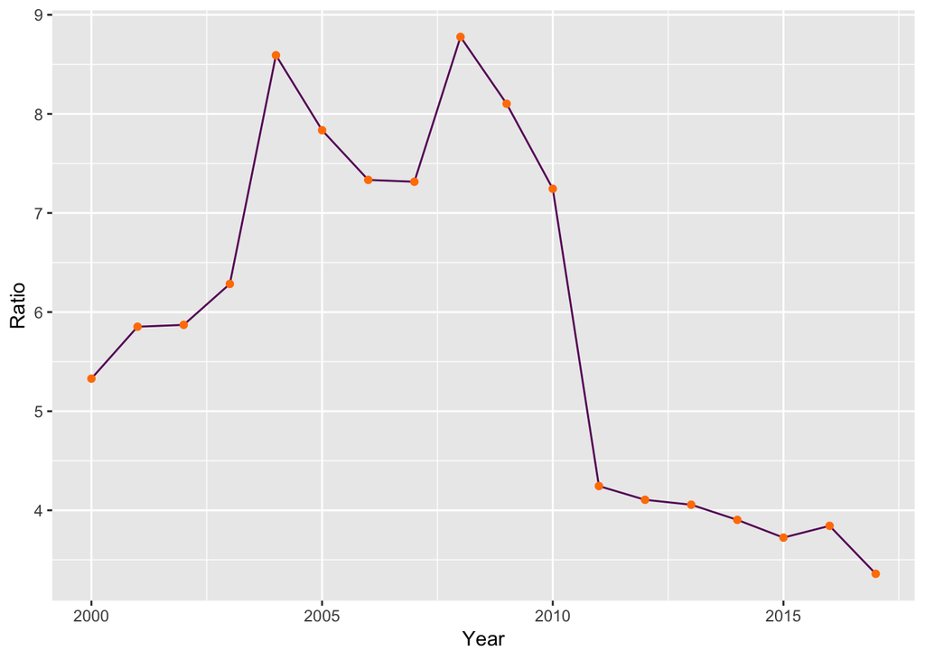

```
##    Year Beijing_Enterprise Beijing_Output Tianjin_Enterprise
## 1  2000               4572        2565.38               5430
## 2  2001               4356        2908.82               5561
## 3  2002               4551        3173.48               5346
## 4  2003               4019        3810.36               5341
## 5  2004               6871        4880.89               6462
## 6  2005               6300        6946.07               6144
## 7  2006               6400        8210.00               6301
## 8  2007               6397        9648.38               6361
## 9  2008               7205       10413.09               7950
## 10 2009               6890       11039.13               8326
## 11 2010               6884       13699.84               7947
## 12 2011               3746       14513.63               5013
## 13 2012               3692       15596.21               5342
## 14 2013               3641       17370.88               5511
```

[output cut: 384 more lines]

From our line plots, we can see certain provinces such as Beijing, Tianjin, Shanxi, and Shanghai have similar plotted trajectories to our growth rate function. This could be illuminated by the fact that these provinces have significantly higher Investment in Fixed Assets (National Bureau of Statistics) as compared to the other provinces as well as higher Number of Employed Personnel, transforming the Enterprise/Population metric into more of a productive unit of value/person metric, which also makes sense as median average wage is higher in Beijing & Shanghai than almost the rest of the provinces listed. I wish I could have expanded more into other variable factors to draw correlations, but I wanted to stay on topic, so those were not included.

[^1]: From Wikipedia - A municipality is often not a “city” in the usual sense of the term (i.e., a large continuous urban settlement), but instead an administrative unit of sorts.